# R for Bioinformatics Workflow - Microbiome Data

Microbiome Data Processing using Phyloseq

Muhammad Naufal Hakim

2026-08-26

# 1 TL;DR

This document is your workbook for Session 2 - R for Bioinformatics Workflow. It mixes explanation with code you run yourself — click the green ▶ button (top-right of each grey box) or press `Ctrl+Enter` / `Cmd+Enter` with your cursor on a line to run it.

**Before you start:**

Run the setup chunk below first — everything depends on it.

```r
library(readr)
library(dplyr)
library(ggplot2)
library(tidyr)
library(phyloseq)
```

If that chunk errors with `there is no package called ...`, run this once in the Console (not in this file), then re-run the chunk above:

```r
install.packages(c("readr", "dplyr", "ggplot2", "tidyr"))
```

```r
if (!require("BiocManager", quietly = TRUE))
    install.packages("BiocManager")

BiocManager::install("phyloseq")
```

# 2 Microbiome 101 - Very Short!

What is microbiome? This figure describes it so well though.

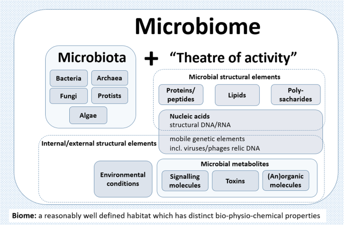

One method (from many) to identify microbiome is using amplicon targeted sequencing, that target special region of DNA, such as 16s rRNA (bacteria), ITS (fungi or eukaryote) and COI (usually for fish-related).

We can use this DNA region since it contains conserve region, means the region always exist for each organism type, but also contains the hypervariable region, means the region are changed due to organism type.

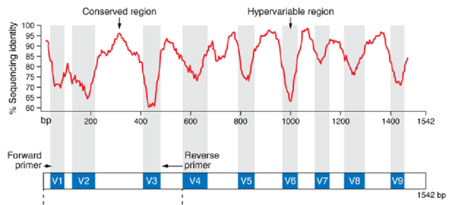

Based on these hypervariable regions, Hulpusch et al (2023) use V1-V3 regions to check the effect of dilution towards synthetic mock community. We will use the result of their research during this session, Bioinformatics Workflow using R.

# 3 Load dataset for phyloseq

`phyloseq` is a library for microbiome workflow in R. The minimal input are **ASV/OTU table** and **taxonomy table**, and the output from these files are called as `phyloseq object`.

```r
# Load dataset

otu_file <- "/Users/hakimbazol/Documents/03_projects/r_for_biological_data_analysis/session2/otu.tsv"
tax_file <- "/Users/hakimbazol/Documents/03_projects/r_for_biological_data_analysis/session2/tax.tsv"
meta_file <- "/Users/hakimbazol/Documents/03_projects/r_for_biological_data_analysis/session2/metadata.tsv"

otu <- read.delim(otu_file, header = TRUE, row.names = 1, sep = "\t", check.names = FALSE)
tax <- read.delim(tax_file, header = TRUE, row.names = 1, sep = "\t", check.names = FALSE)
meta <- read.delim(meta_file, header = TRUE, row.names = 1, sep = "\t", check.names = FALSE)
tax[tax == "unidentified"] <- NA

# Preparation for phyloseq file

otu <- otu_table(as.matrix(otu), taxa_are_rows = TRUE)
tax <- tax_table(as.matrix(tax))
meta <- sample_data(meta)

# Making phyloseq object

ps <- phyloseq(otu, tax, meta)
ps
```

```
## phyloseq-class experiment-level object
## otu_table()   OTU Table:         [ 301 taxa and 23 samples ]
## sample_data() Sample Data:       [ 23 samples by 5 sample variables ]
## tax_table()   Taxonomy Table:    [ 301 taxa by 7 taxonomic ranks ]
```

```r
# Save as RDS object. Change the address based on your working directory.

saveRDS(ps, "/Users/hakimbazol/Documents/03_projects/r_for_biological_data_analysis/session2/ps.rds")
```

# 4 Taxabar Plot

Taxabar Plot is a stacked-bar plot, contains taxa for all samples that are expressed as relative abundance (%), which is obtained from fraction of taxa divided by sum of taxa in a sample.

[figure not shown]

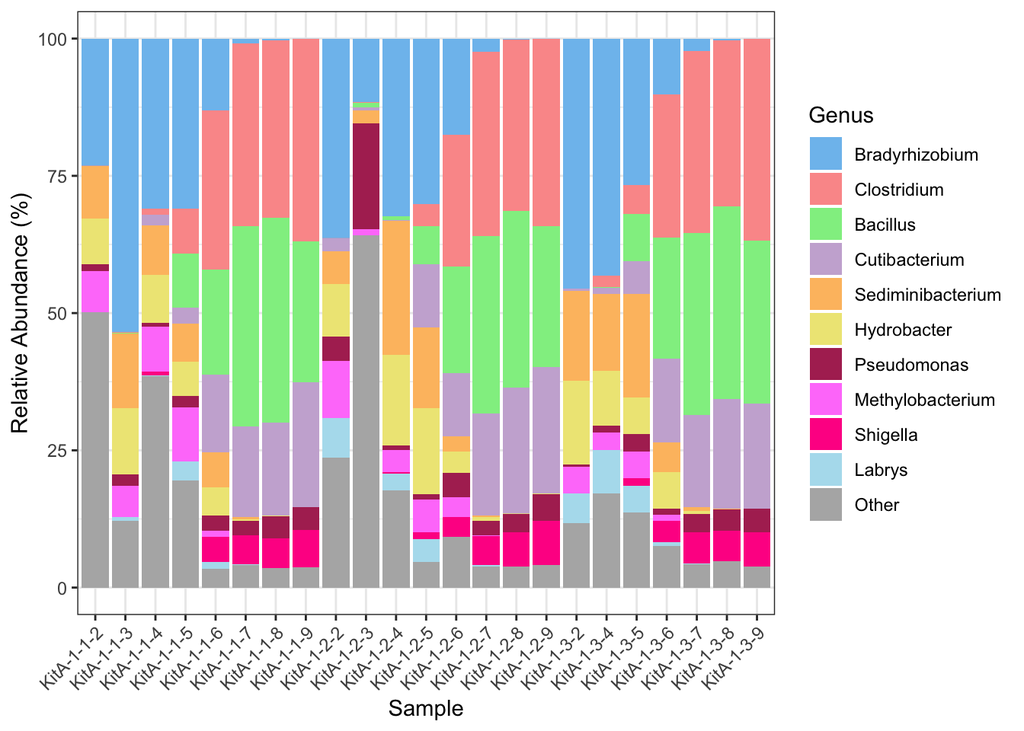

```r
# Start here. This is taxabar plot that will show top n taxa within samples.

tax_rank <- "Genus"        # "Phylum"/"Class"/"Order"/"Family"/"Genus"/...
top_n <- 10                # keep top N taxa by mean abundance

# Load color
c17_pastel<- c("skyblue2", "#FB9A99", "palegreen2","#CAB2D6", "#FDBF6F", "khaki2",
               "maroon", "orchid1", "deeppink1", "lightblue2", "steelblue4",
               "darkturquoise", "darkorange4", "brown", "#FF7F00", "gold1","#6A3D9A")


# Set color for "Other category"
other_color <- "gray70"

# 1) Agglomerate at chosen taxonomic rank. tax_glom() is a Phyloseq function to agglomerate taxa based on a taxonomic level
ps_rank <- tax_glom(ps, taxrank = tax_rank)

# 2) Convert to relative abundance per sample. transform_sample_counts() will convert each taxa into relative abundance based on total reads.
ps_rel <- transform_sample_counts(ps_rank, function(x) (x / sum(x)*100))

# 3) Melt to long dataframe
df <- psmelt(ps_rel)

# 4) Summarise abundance per Sample x Taxon
df_summary <- df %>%
  group_by(Sample, .data[[tax_rank]]) %>%
  summarise(Abundance = sum(Abundance), .groups = "drop")

# 5) Find TOP N taxa by mean abundance across samples
top_taxa <- df_summary %>%
  group_by(.data[[tax_rank]]) %>%
  summarise(mean_abundance = mean(Abundance), .groups = "drop") %>%
  arrange(desc(mean_abundance)) %>%
  slice_head(n = top_n) %>%
  pull(.data[[tax_rank]])

# 6) Collapse everything else into "Other"
df_summary <- df_summary %>%
  mutate(
    !!tax_rank := ifelse(.data[[tax_rank]] %in% top_taxa, .data[[tax_rank]], "Other")
  ) %>%
  group_by(Sample, .data[[tax_rank]]) %>%
  summarise(Abundance = sum(Abundance), .groups = "drop")

# 7) Order taxa by mean abundance (descending) but force "Other" last
tax_order <- df_summary %>%
  group_by(.data[[tax_rank]]) %>%
  summarise(mean_abundance = mean(Abundance), .groups = "drop") %>%
  arrange(desc(mean_abundance)) %>%
  pull(.data[[tax_rank]])

tax_order <- c(setdiff(tax_order, "Other"), "Other")

df_summary <- df_summary %>%
  mutate(!!tax_rank := factor(.data[[tax_rank]], levels = tax_order))

# Color map
color_map <- setNames(c(c17_pastel[1:(length(tax_order)-1)], other_color), tax_order)

ggplot(df_summary, aes(x = Sample, y = Abundance, fill = .data[[tax_rank]])) +
  geom_col() +
  theme_bw() +
  theme(axis.text.x = element_text(angle = 45, hjust = 1, vjust = 1)) +
  scale_fill_manual(values = color_map) +
  labs(x = "Sample", y = "Relative Abundance (%)", fill = tax_rank)
```

# 5 Alpha Diversity

Alpha diversity is a calculation of taxa availability (richness) and the evenness of taxa within a community. The ability to define alpha diversity is important, since based on this metrics, we are able to determine which community with diverse microbiome, or even whether the community is dominated by one or some taxa.

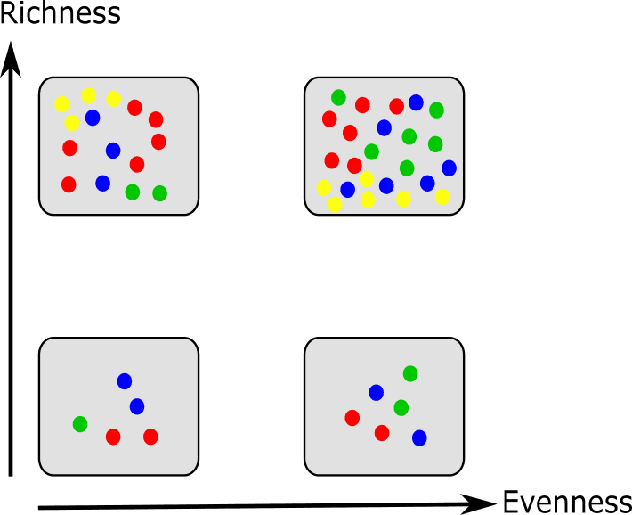

## 5.1 Alpha diversity calculation

```r
# Agglomerate taxa, since alpha diversity may differ based on different taxonomic level

ps_glom_genus <- tax_glom(ps, taxrank=rank_names(ps)[6])

# Calculate alpha diversity, using pre-installed library in phyloseq

alpha <- estimate_richness(ps_glom_genus,
                           measures = c("Observed",
                                        "Shannon"
                                        )) %>%
  dplyr::rename(Richness = Observed)

rownames(alpha) <- gsub("\\.", "-", rownames(alpha))

# Show alpha diversity table

alpha
```

```
##            Richness  Shannon
## KitA-1-1-2       18 2.328864
## KitA-1-1-3       15 1.605126
## KitA-1-1-4       26 2.437193
## KitA-1-1-5       14 2.299631
## KitA-1-1-6       22 2.091197
## KitA-1-1-7       22 1.585068
## KitA-1-1-8       15 1.522208
## KitA-1-1-9       11 1.544935
## KitA-1-2-2       21 2.276983
## KitA-1-2-3       54 3.214914
## KitA-1-2-4       25 2.030531
## KitA-1-2-5       16 2.108401
## KitA-1-2-6       21 2.234170
## KitA-1-2-7       21 1.668495
## KitA-1-2-8       13 1.557429
## KitA-1-2-9       13 1.601891
## KitA-1-3-2       16 1.741559
## KitA-1-3-4       24 2.082544
## KitA-1-3-5       20 2.387662
## KitA-1-3-6       21 2.166730
## KitA-1-3-7       23 1.689042
## KitA-1-3-8       15 1.580206
## KitA-1-3-9       12 1.538667
```

## 5.2 Alpha diversity plot

Before we are going to observe the alpha diversity, there are some things that we need to do!

1. Merge the calculation result with metadata (we get if from Phyloseq object)
2. Make the data in long format using `pivot_longer()` function
3. Finally, the data is ready to plot!

Let’s breakdown all the step below!

### 5.2.1 Alpha diversity merging with metadata

```r
# Since the data is quite many, I subset the data up until D3. Feel free to try for more data!
# As we have category and values, the visualization that able to cover that is boxplot.

# Prepare the dataset

meta <- data.frame(sample_data(ps))

alpha_w_metadata <- merge(alpha,
                          meta,
                          by = 0)

# Subset the metadata up until D3

alpha_w_metadata_d3 <- alpha_w_metadata %>%
  filter(Dilution %in% c("D0", "D1", "D2", "D3"))

alpha_w_metadata_d3
```

```
##     Row.names Richness  Shannon Sample_type DNA_conc Input_cells Dilution
## 1  KitA-1-1-6       22 2.091197      SAMPLE 11.83011       1e+06       D3
## 2  KitA-1-1-7       22 1.585068      SAMPLE 21.61867       1e+07       D2
## 3  KitA-1-1-8       15 1.522208      SAMPLE 32.26394       1e+08       D1
## 4  KitA-1-1-9       11 1.544935      SAMPLE 53.22639       1e+09       D0
## 5  KitA-1-2-6       21 2.234170      SAMPLE 13.06963       1e+06       D3
## 6  KitA-1-2-7       21 1.668495      SAMPLE 17.97910       1e+07       D2
## 7  KitA-1-2-8       13 1.557429      SAMPLE 32.32471       1e+08       D1
## 8  KitA-1-2-9       13 1.601891      SAMPLE 52.67955       1e+09       D0
## 9  KitA-1-3-6       21 2.166730      SAMPLE 10.62705       1e+06       D3
## 10 KitA-1-3-7       23 1.689042      SAMPLE 17.36541       1e+07       D2
## 11 KitA-1-3-8       15 1.580206      SAMPLE 34.81590       1e+08       D1
## 12 KitA-1-3-9       12 1.538667      SAMPLE 46.48195       1e+09       D0
##    SourceSink
## 1        Sink
## 2        Sink
## 3        Sink
## 4        Sink
## 5        Sink
## 6        Sink
## 7        Sink
## 8        Sink
## 9        Sink
## 10       Sink
## 11       Sink
## 12       Sink
```

### 5.2.2 Make the data in long format using `pivot_longer()`

```r
# As we have category and values, the visualization that able to cover that is boxplot.
# Making dataset as in long format

alpha_diversity_joint <- alpha_w_metadata_d3 %>%
  pivot_longer(cols = c(Shannon, Richness),
               names_to = "variable",
               values_to = "value")

alpha_diversity_joint
```

```
## # A tibble: 24 × 8
##    Row.names Sample_type DNA_conc Input_cells Dilution SourceSink variable value
##    <chr>     <chr>          <dbl>       <dbl> <chr>    <chr>      <chr>    <dbl>
##  1 KitA-1-1… SAMPLE          11.8     1000000 D3       Sink       Shannon   2.09
##  2 KitA-1-1… SAMPLE          11.8     1000000 D3       Sink       Richness 22
##  3 KitA-1-1… SAMPLE          21.6    10000000 D2       Sink       Shannon   1.59
##  4 KitA-1-1… SAMPLE          21.6    10000000 D2       Sink       Richness 22
##  5 KitA-1-1… SAMPLE          32.3   100000000 D1       Sink       Shannon   1.52
##  6 KitA-1-1… SAMPLE          32.3   100000000 D1       Sink       Richness 15
##  7 KitA-1-1… SAMPLE          53.2  1000000000 D0       Sink       Shannon   1.54
##  8 KitA-1-1… SAMPLE          53.2  1000000000 D0       Sink       Richness 11
##  9 KitA-1-2… SAMPLE          13.1     1000000 D3       Sink       Shannon   2.23
## 10 KitA-1-2… SAMPLE          13.1     1000000 D3       Sink       Richness 21
## # ℹ 14 more rows
```

### 5.2.3 `ggplot()` ready to take action!

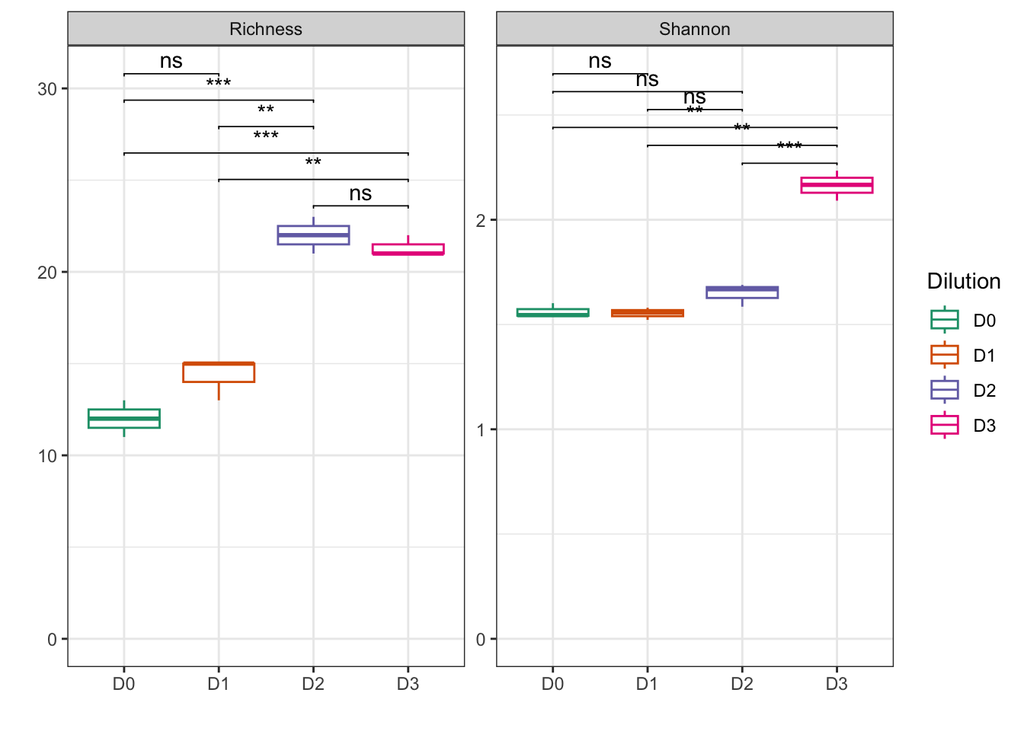

```r
# As we have category and values, the visualization that able to cover that is boxplot.

# Define group for statistical test
group_list <- unique(alpha_w_metadata_d3$Dilution)

# Making comparisons that we compare in the plot
my_comparisons <- combn(group_list, 2, simplify = F)

# Plot the alpha diversity based on specific category
ggplot(alpha_diversity_joint,
       aes(x = Dilution,
           y = value,
           color = Dilution )) +

# Define boxplot for drawing
    geom_boxplot() +

# Define statistical test for drawing
  ggpubr::stat_compare_means(method = "t.test", label = "p.signif",
                               comparisons = my_comparisons,
                               tip.length = 0.01,
                               label.y.npc = "0.5") +

# Define color set. You can browse many color that is available in R.
# See it in https://r-graph-gallery.com/38-rcolorbrewers-palettes.html

  scale_color_brewer(palette = "Dark2") +

# Making limit of y-axis

  ylim(0, NA) +

# Define theme and making no label in x and y axis

  theme_bw() +

  labs(x = "", y = "") +

# Separate the plot using specific column

  facet_wrap(~variable, scales = "free_y")
```

# 6 Read the microbiome data - How to decrypt it?

As a bioinformatician, all workflow that I already taught **means NOTHING** if we cannot explain what happens **biologically** to the audience.

As a training, based on our activities, anyone that would like to explain how to read the microbiome data?

# 7 End of Session 2

This is the end of session 2. Thank you for joining us!